# VAR Selection

# Chargement des librairies

```r
# install.packages("MultiVarSel_1.0.tar.gz",repos=NULL)
library(MultiVarSel)
library(reshape)
library(ggplot2)
library(knitr)
library(FactoMineR)
library(factoextra)
library(dplyr)
```

# Import des données

```r
table<-read.table("../Table_proteome_FH_all.csv", sep=";", dec=",", header=T,row.names=1)
dim(table)
```

```
[1]  27 498
```

## Ajout du facteur temperature pour caractériser les echantillons

```r
### Creation d'une variable qualitative supplementaire pour enlever les replicats
temperature<-factor(rep(c("Low","Medium","Elevated"),each=3),levels=c("Low","Medium","Elevated"))
imbibition<-factor(rep(c("DS", "EI", "LI"), each=3), levels=c("DS", "EI", "LI"))
imbibition_Temp<-factor(rep(c("Low_DS", "Low_EI", "Low_LI", "Medium_DS", "Medium_EI", "Medium_LI", "Elevated_DS", "Elevated_EI", "Elevated_LI"), each=9), levels=c("Low_DS", "Low_EI", "Low_LI", "Medium_DS", "Medium_EI", "Medium_LI", "Elevated_DS", "Elevated_EI", "Elevated_LI"))
```

## Vérification de la présence de col dont les valeures ne bougent jamais et d’éventuelles données manquantes

```r
which(is.na(table))
```

```
integer(0)
```

# Construction de la matrice

```r
table2 <- table[,c(1,5:ncol(table))]
Y <- as.matrix(table2[, -(1)])
X1 <- table2[, 1]
```

```r
table[,15]
```

```
 [1] 7.133731 7.071768 7.164342 7.030696 7.429855 7.197566 7.557435 7.392318 7.450475 7.198908 7.498931 7.681823 7.317193
[14] 7.030696 7.205809 7.345025 7.294131 7.241614 7.437790 7.511676 7.503292 7.289651 7.151711 7.397379 7.392605 7.329954
[27] 7.409679
```

```r
library(rstatix)
shapiro_test(Y[,15])
```

| variable | statistic | p.value |
| --- | --- | --- |
| Y[, 15] | 0.9305781 | 0.07140357 |

```r
library(rstatix)

# Créer une fonction de test de normalité
shapiro.test <- function(x) {
  shapiro_test(x)
}

gauss_transform <- function(data) {
  # Appliquer la transformation logarithmique
  data <- log(data)
  # Retourner les données transformées
  return(data)
}

# Appliquer la fonction à un dataframe
test_normalite <- function(dataframe) {
  nbr_col <- 0
  for (col in colnames(dataframe)) {
    shapiro.test_result <- shapiro.test(dataframe[, col])
    if (shapiro.test_result$p.value > 0.05) {
      dataframe[, col] <- gauss_transform(dataframe[, col])
      nbr_col <- nbr_col + 1
    }
  }
  print(nbr_col)
  return (dataframe)
}

# Appliquer la fonction à un dataframe
Y <- test_normalite(Y)
```

```
[1] 387
```

```r
B <- model.matrix(lm(Y ~ (X1) + 0)) # matrices de design
```

```r
q=dim(Y)[2]
print(q)
```

```
[1] 494
```

```r
Yscaled = scale(Y) # Normalization
residuals=lm(as.matrix(Yscaled)~B-1)$residuals
```

We apply the whitening test to this residuals matrix in order to know if it is useful to whiten the observations or not

```r
pvalue=whitening_test(residuals)
# Cette fonction calcule la somme des carrés des coefficients de corrélation partiels (ACF) d'un vecteur de résidus donné.
pvalue
```

```
[1] 0.7556099
```

P value est trop forte donc on peut pas refuser h0

```r
result=whitening_choice(residuals,c("AR1","nonparam","ARMA"),pAR=1,qMA=1)
result
```

|  | Pvalue | Decision |
| --- | --- | --- |
| AR1 | 0.758 | WHITE NOISE |
| nonparam | 0.997 | WHITE NOISE |
| ARMA 1 1 | 0.761 | WHITE NOISE |

# Anova séparée, métabolite par métabolite

```r
select_per_anova=c()
for(i in 3:ncol(table2)){
  res.anova<-lm(table2[,i]~table2[,2], data=table2)
  pvalue.anova=c()
  pvalue.anova<-anova(res.anova)$'Pr(>F)'[1]
  if(pvalue.anova<0.05/q){
    select_per_anova=c(select_per_anova,colnames(table2)[i])}}
length(select_per_anova)
```

```
[1] 23
```

Que les pvalues sont fortes bah on peut utiliser les 2. On pourrait tester avec des param du style AR31

The non parametric choice has the highest p-value. We select this dependence to model the residuals. We compute the square root of the inverse of the estimator of the covariance matrix of each row of the residuals matrix using the non parametric modelling as follows:

```r
square_root_inv_hat_Sigma=whitening(residuals,"nonparam",pAR=1,qMA=0)

# Estimation de sigma chapeau - 1/2
# La méthode "nonparam" indique que la méthode de blanchiment sera non paramétrique. Les paramètres pAR et qMA déterminent le nombre de paramètres autoregressifs et de moyennes mobiles à utiliser dans le modèle, et ici ils sont définis à 1 et 0 respectivement.
```

```r
library(parallel)
require(doMC)
registerDoMC(cores=6)
Freqs2=variable_selection(Yscaled,B,square_root_inv_hat_Sigma, nb_repli=50000,parallel=TRUE,nb.cores=6)

save(Freqs2, file='./tables_output/50000_nonparam_blanchi_2022.Rdata')
```

```r
load('./tables_output/5000_non_blanchi_2022.Rdata')
```

[figure not shown]

```r
colnames(Freqs2)<-c('Names_of_Y','Names_of_X','frequency')
plot(sort(Freqs2$frequency,decreasing = T),type='s')
```

```r
sort(Freqs2$frequency,decreasing = T)[1:50]
```

```
 [1] 0.7482 0.7390 0.7356 0.7260 0.7200 0.7122 0.7042 0.6940 0.6896 0.6722 0.6672 0.6656 0.6654 0.6600 0.6582 0.6540
[17] 0.6500 0.6278 0.6258 0.6238 0.6218 0.6194 0.6192 0.6186 0.6148 0.6148 0.6124 0.6098 0.6068 0.6034 0.6014 0.5984
[33] 0.5978 0.5954 0.5758 0.5748 0.5730 0.5696 0.5686 0.5668 0.5644 0.5644 0.5642 0.5622 0.5606 0.5600 0.5600 0.5584
[49] 0.5566 0.5558
```

```r
seuil_non_blanchi=0.65
Freqs2$Names_of_X=gsub(pattern='temperature',replacement='',Freqs2$Names_of_X)
indices=which(Freqs2$frequency>=seuil_non_blanchi)
length(indices)
```

```
[1] 17
```

```r
Yvec=as.numeric(Yscaled%*%square_root_inv_hat_Sigma)
Xvec=kronecker(t(square_root_inv_hat_Sigma),B)
Xvec_sel=as.matrix(Xvec[,indices])
B_sel_hat=solve(t(Xvec_sel)%*%Xvec_sel,t(Xvec_sel)%*%Yvec)
Freqs2$estim=rep(0,p*q)
Freqs2$estim[indices]=as.vector(B_sel_hat)
```

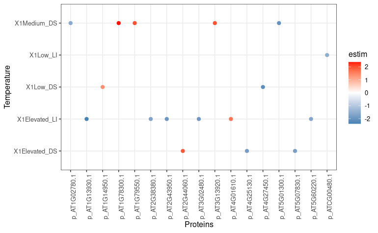

```r
gr<-ggplot(data=Freqs2[Freqs2$frequency>=seuil_non_blanchi,],
           aes(x=Names_of_Y,y=Names_of_X,color=estim))+
        scale_color_gradient2(low="steelblue",mid = "white", high ="red")+
    geom_point(size=2)+theme_bw()+ylab('Temperature')+xlab('Proteins')+theme(axis.text.x = element_text(angle=90))
gr
```

```r
dim(Xvec)
```

```
[1] 13338  4446
```

```r
table_red=as.data.frame(Yscaled[,colnames(Yscaled)%in%unique(Freqs2[indices,]$Names_of_Y)])

table_red$imbibition_Temp=table2[,1]
bp <- ggplot(melt(table_red), aes(x=imbibition_Temp, y=value,fill=imbibition_Temp)) +
  geom_boxplot()+theme_bw()
```

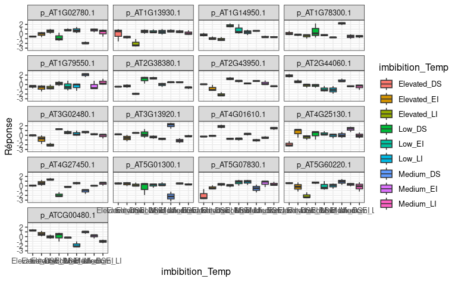

```r
bp+facet_wrap(~variable,ncol=4)+ylab("Réponse")
```

#Heatmap

```r
library(pheatmap)
library(RColorBrewer)
```

```r
tableVP <- table2[,test]
tableVP <- scale(tableVP)
```